# TASK 2

The diffusion equation is given by:

$$ \frac{\partial \overline B_r}{\partial t} = - \frac{\overline V}{r} \frac{\partial}{\partial r}(r\overline B_r) - \frac{\partial}{\partial z}(\overline V_z \overline B_r) - \frac{\partial}{\partial z}(\alpha \overline B_{\phi}) + \eta_t \left[ \frac{\partial}{\partial r} \left( \frac{1}{r} \frac{\partial}{\partial r}(r \overline B_r)\right) + \frac{\partial ^2 \overline B_r}{\partial z^2} \right] $$$$ \frac{\partial \overline B_{\phi}}{\partial t} = - q\Omega \overline B_{r} - \frac{\partial}{\partial r}(\overline V_r \overline B_{\phi}) - \frac{\partial}{\partial z}(\overline V_z \overline B_{\phi}) + \frac{\partial}{\partial z}(\alpha \overline B_{r}) + \eta_t \left[ \frac{\partial}{\partial r} \left( \frac{1}{r} \frac{\partial}{\partial r}(r \overline B_{\phi})\right) + \frac{\partial ^2 \overline B_{\phi}}{\partial z^2} \right] $$

dimensionless forms of diffusion equation is given by:

$$ \frac{\partial B_r}{\partial t}=-\frac{V_r}{r}\frac{\partial }{\partial r}(r B_r)+\frac{\partial }{\partial z}(V_z B_r)-\frac{\partial }{\partial z}(\alpha B_{\phi})+\frac{\partial }{\partial r}\left(\frac{\partial }{r \partial r}(r B_{\phi})\right)+\frac{\partial^2 B_r}{\partial z ^2} $$$$ \frac{\partial B_{\phi}}{\partial t}=-q\Omega B_r-\frac{\partial }{\partial r}(V_r B_{\phi})+\frac{\partial }{\partial z}(V_z B_{\phi})-\frac{\partial }{\partial z}(\alpha B_r)+\frac{\partial }{\partial r}\left(\frac{\partial }{r \partial r}(r B_{\phi})\right)+\frac{\partial^2 B_r}{\partial z ^2} $$

After omitting the $\nabla \times (\mathbf{V} \times \mathbf{B})$ terms, equations are :

$$\frac{\partial B_r '}{\partial t'}=-\frac{\partial (\alpha ' B_{\phi}')}{\partial z'}+\frac{\partial^2 B_r'}{\partial z ^{'2}}$$$$\frac{\partial B_{\phi}'}{\partial t'}=\frac{D}{\alpha_0 '} B_{r} '+\frac{\partial^2 B_{\phi} '}{\partial z^{'2} }$$$$D=-\frac{q\Omega \alpha _0 h^3}{\eta _t^2}$$

for galaxies, q>0 and D<0

we have used second order finite difference method for calculating the spatial derivatives and RK4 for the time stepping.

### **defining methods**

- 2nd order finite difference method for spatial derivatives
- Runge-kutta method for time stepping

### **Implementing and plotting the result**

##### **pitch angle:**

$\arctan \left( \frac{B_r}{B_{\phi}} \right)$ is the pitch angle and it plotted against z at different time points

##### **exponential decay rate:**

```python
import numpy as np
import matplotlib.pyplot as plt
import scipy
import math


# finite difference method to calculate the second derivative of a function
def d2f(f, dz, Nz):
    sol = np.zeros((Nz))  # Initialize solution array
    for i in range(1, Nz - 2):
        sol[i] = (f[i - 1] - 2 * f[i] + f[i + 1]) / (dz * dz)
    # Apply boundary conditions at i=0
    sol[0] = (2 * f[0] - 5 * f[1] + 4 * f[2] - f[3]) / (dz * dz)
    # Apply boundary conditions at i=Nz-1
    sol[Nz - 1] = (2 * f[Nz - 1] - 5 * f[Nz - 2] + 4 * f[Nz - 3] - f[Nz - 4]) / (dz * dz)
    return sol

def df(f,dz,Nz):
    sol = np.zeros((Nz))
    i=0
    sol[i]=((2*f[i])-(5*f[i+1])+(4*f[i+2])-f[i+3])/(dz*dz)
    i=Nz-1
    sol[i]=((2*f[i])-(5*f[i-1])+(4*f[i-2])-f[i-3])/(dz*dz)
    for i in range(1,Nz-2):
        sol[i]=(f[i-1]+(-2*f[i])+f[i+1])/(dz*dz)
    return sol

def solve2(Br_t0,Bphi_t0,Nz,Nt,time_plot,Bphi_z0,Bphi_zf,Br_z0,Br_zf,D):
    #intials()
    Br=[]
    Bphi=[]
    decay=[]

    if 0 in time_plot:
        Br.append(Br_t0)
        Bphi.append(Bphi_t0)


    for j in range(0, Nt + 1):

        k1r = dBrdt(Br_t0,Bphi_t0,z,D,alpha,dz,Nz)
        k1phi = dBphidt(Br_t0,Bphi_t0,z,D,alpha,dz,Nz)

        k2r = dBrdt(Br_t0+k1r*dt/2, Bphi_t0+k1phi*dt/2, z,D,alpha,dz,Nz)
        k2phi = (dBphidt(Br_t0+k1r*dt/2, Bphi_t0+k1phi*dt/2, z,D,alpha,dz,Nz))

        k3r = (dBrdt(Br_t0+k2r*dt/2,Bphi_t0+k2phi*dt/2,z,D,alpha,dz,Nz))
        k3phi = (dBphidt(Br_t0+k2r*dt/2,Bphi_t0+k2phi*dt/2,z,D,alpha,dz,Nz))

        k4r = (dBrdt(Br_t0+k3r*dt,Bphi_t0+k3phi*dt/2,z,D,alpha,dz,Nz))
        k4phi = (dBphidt(Br_t0+k3r*dt/2,Bphi_t0+k3phi*dt,z,D,alpha,dz,Nz))
        Br_t0 = Br_t0 + ((dt / 6.0) * (k1r +( 2 * k2r) + (2 * k3r) + k4r))

        Bphi_t0 = Bphi_t0 + ((dt / 6.0) * (k1phi + (2 * k2phi) + (2 * k3phi) + k4phi))

        #(Anti Symmetric Ghost Zone)
        Bphi_t0[1]=Bphi_z0
        Br_t0[Nz-2]=Br_zf
        Br_t0[1]=Br_z0
        Bphi_t0[Nz-2]=Bphi_zf
        Br_t0[Nz-1]=Br_z0-Br_t0[Nz-3]
        Bphi_t0[Nz-1]=Bphi_z0-Bphi_t0[Nz-3]
        Br_t0[0]=Br_z0-Br_t0[2]
        Bphi_t0[0]=Bphi_z0-Bphi_t0[2]

        decay.append(np.log10(np.sqrt((np.mean(Br_t0))**2+(np.mean(Bphi_t0))**2)))

        if j in time_plot:
            Br.append(Br_t0)
            Bphi.append(Bphi_t0)
            #B_pitch.append(np.copy(B))

    pitch=np.arctan(np.array(Br)/np.array(Bphi))
    return Br,Bphi,pitch,decay


def plotfn(Br, Bphi, pitch, decay, time_plot,t,z,Nz):
    m, b = np.polyfit(t, decay, 1)

    fig, ax = plt.subplots(2, 2, figsize=(15, 10))

    for i in range(len(time_plot)):
        ax[0, 0].plot(z[1:Nz-1], Br[i][1:Nz-1], label=f't={time_plot[i]}')
        ax[0, 1].plot(z[1:Nz-1], Bphi[i][1:Nz-1], label=f't={time_plot[i]}')
        ax[1, 1].plot(z[1:Nz-1], pitch[i][1:Nz-1], label=f't={time_plot[i]}')

    ax[0, 0].set_xlabel('z')
    ax[0, 0].set_ylabel('Br')
    ax[0, 0].set_title('Br vs z')
    ax[0, 0].legend()

    ax[0, 1].set_xlabel('z')
    ax[0, 1].set_ylabel(r'$B_{\phi}$')
    ax[0, 1].set_title(r'$B_{\phi}$ vs z')
    ax[0, 1].legend()

    ax[1, 0].scatter(t, decay)
    ax[1, 0].plot(t, m*t+b,color='Red', label='linear fit')
    ax[1, 0].set_xlabel('t')
    ax[1, 0].set_ylabel('log(B)')
    ax[1, 0].set_title('exponential decay rate')

    #ax[1, 1].plot(z, pitch)
    ax[1, 1].set_xlabel('z')
    ax[1, 1].set_ylabel('pitch angle')
    ax[1, 1].set_title('pitch angle vs z')

    plt.tight_layout()
    plt.show()
    print("The Decay rate is",np.round((m*np.log(10)),4))



def D_c(solve2,precision):
    D=0
    h=2
    while h>precision:
        drate=-1 #dummy value
        print('current |D| =',D)
        while drate<0:
            Br,Bphi,pitch,decay=solve2(Br_t0,Bphi_t0,Nz,Nt,time_plot,Bphi_z0,Bphi_zf,Br_z0,Br_zf,-D)
            m, c = np.polyfit(t, decay , 1)
            drate=m*np.log(10)
            print('|D| =',D,' | decay rate =',drate)
            D=D+h
        D=D-2*h
        h=h/2
    print("Critical dynamo number, |D_c| =",D+h/2)
    #return D+h/2
```

```python
def Bphi_t0(z):
    return 6*np.sin((np.pi)*z/2)+np.sin(np.pi*z*3)

def Br_t0(z):
    return 6*np.sin((np.pi)*z)


def alphafn(r):
    return (-1)
def dBrdt(Br_t0,Bphi_t0,z,D,alpha,dz,Nz):
    return (d2f(Br_t0,dz,Nz)-df(alpha*alphafn(z)*Bphi_t0,dz,Nz))
def dBphidt(Br_t0,Bphi_t0,z,D,alpha,dz,Nz):
    return (d2f(Bphi_t0,dz,Nz)+((D/alpha)*Br_t0))


z0 = 0.0  # start of spatial region in z
zf = 2.0  # end of spatial domain in z
t0=0.0
tf = 3.0
Nz = 101  # Number of spatial grid points
Nt = 15000  # Number of time steps
dz = (zf - z0) / (Nz - 1)  # Spatial step size
dt = tf / Nt  # Time step size



z = np.linspace(z0, zf, Nz)
t = np.linspace(t0, tf, Nt+1)

Br_t0=Br_t0(z)
Bphi_t0=Bphi_t0(z)

Bphi_z0=0
Bphi_zf=0
Br_z0=0
Br_zf=0

#print(Bphi_z0,Bphi_zf,Br_z0,Br_zf)
time_plot=[0,int(Nt/10),int(Nt/5),int(Nt/2),int(Nt/1.5),int(Nt/1.2),int(Nt/1.1),Nt]
```

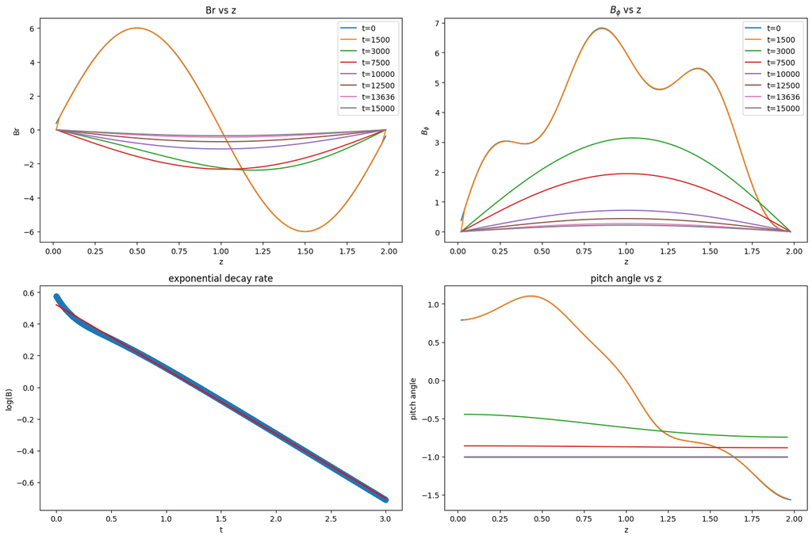

```
The Decay rate is -0.9383
```

```python
D, alpha = -1, 1
plotfn(*solve2(Br_t0,Bphi_t0,Nz,Nt,time_plot,Bphi_z0,Bphi_zf,Br_z0,Br_zf,D),time_plot,t,z,Nz)
```

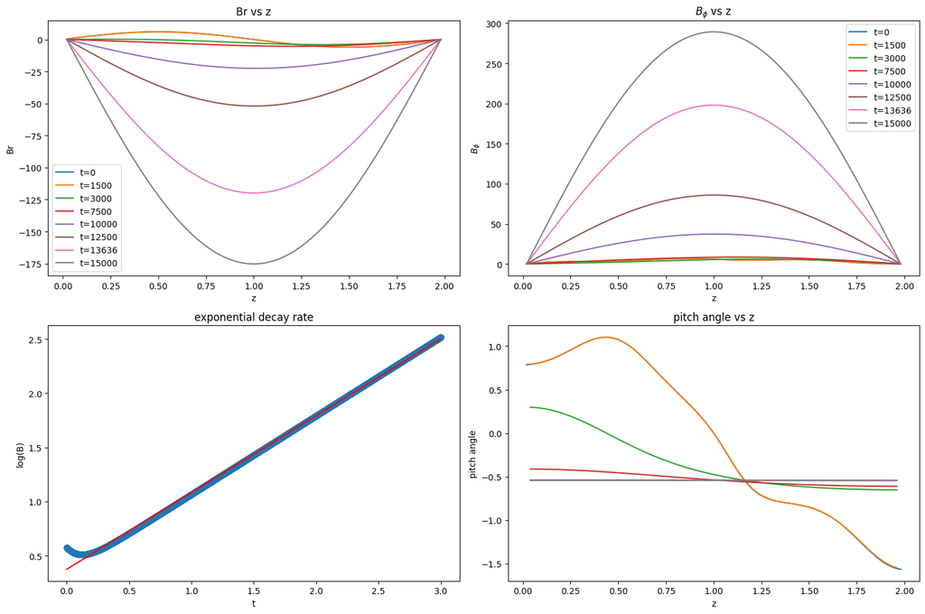

```
The Decay rate is 1.6331
```

```python
D, alpha = -7,1
plotfn(*solve2(Br_t0,Bphi_t0,Nz,Nt,time_plot,Bphi_z0,Bphi_zf,Br_z0,Br_zf,D),time_plot,t,z,Nz)
```

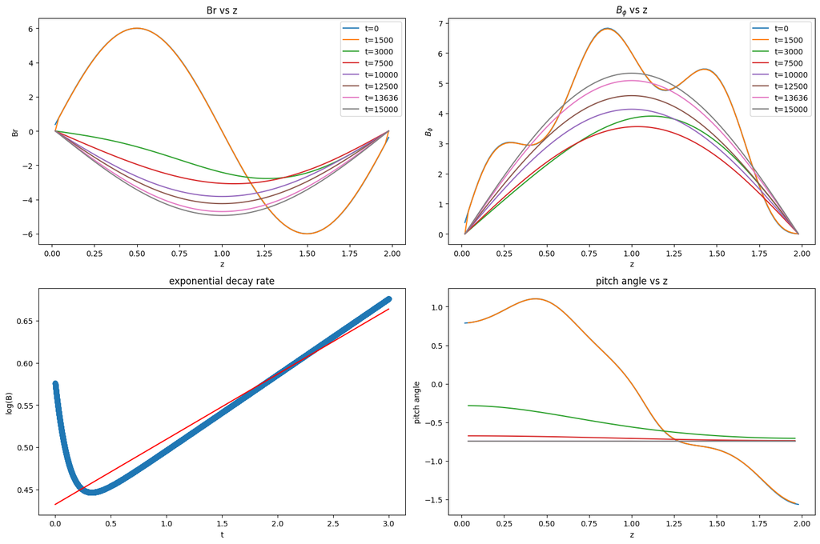

```
The Decay rate is 0.1778
```

```python
D, alpha = -3,1
plotfn(*solve2(Br_t0,Bphi_t0,Nz,Nt,time_plot,Bphi_z0,Bphi_zf,Br_z0,Br_zf,D),time_plot,t,z,Nz)
```

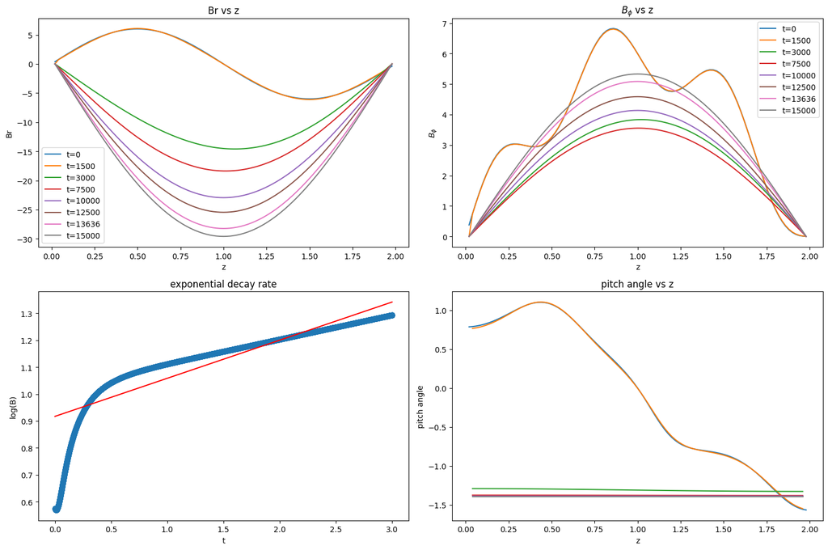

```
The Decay rate is 0.3256
```

```python
D, alpha = -3,6
plotfn(*solve2(Br_t0,Bphi_t0,Nz,Nt,time_plot,Bphi_z0,Bphi_zf,Br_z0,Br_zf,D),time_plot,t,z,Nz)
```

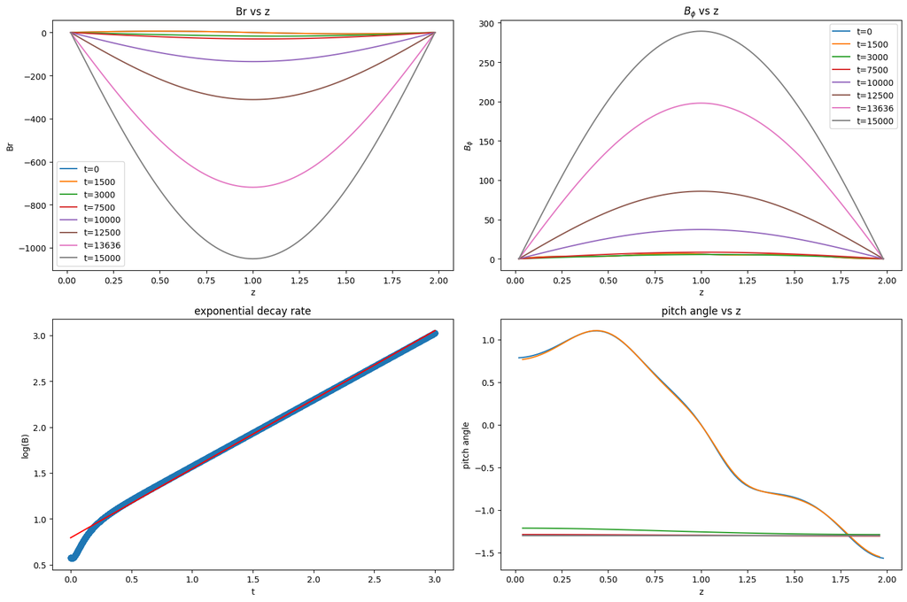

```
The Decay rate is 1.7339
```

```python
D, alpha = -7,6
plotfn(*solve2(Br_t0,Bphi_t0,Nz,Nt,time_plot,Bphi_z0,Bphi_zf,Br_z0,Br_zf,D),time_plot,t,z,Nz)
```

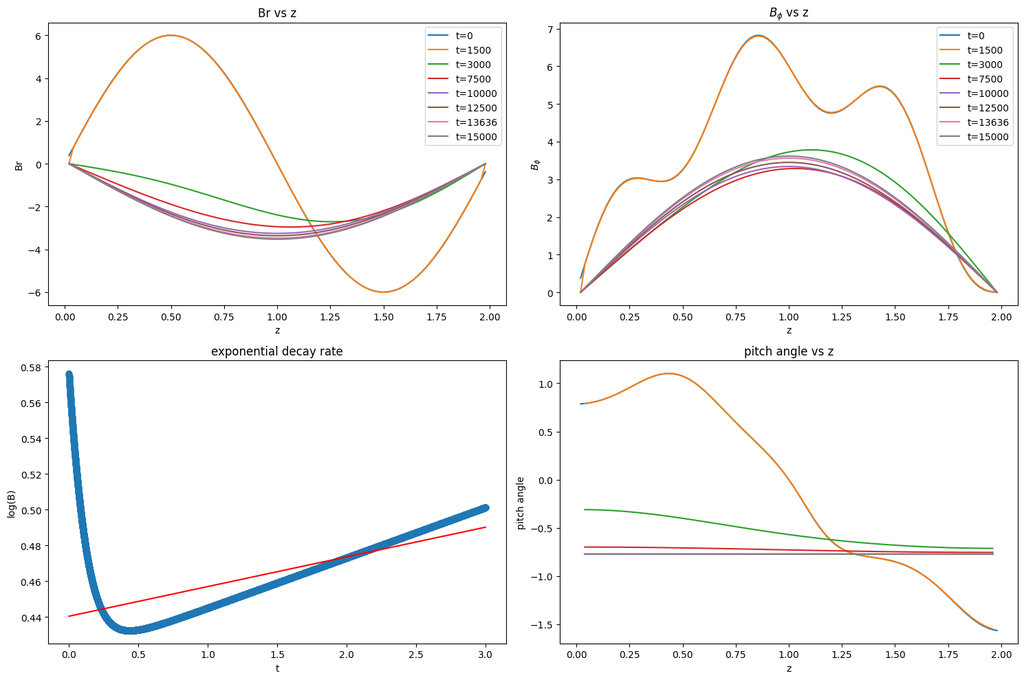

```
The Decay rate is 0.0382
```

```python
D, alpha = -2.7,1
plotfn(*solve2(Br_t0,Bphi_t0,Nz,Nt,time_plot,Bphi_z0,Bphi_zf,Br_z0,Br_zf,D),time_plot,t,z,Nz)
```

```python
alpha=1
precision=0.1
D_c(solve2,precision)
```

```
current |D| = 0
```

```
|D| = 0  | decay rate = -1.8742856224864874
|D| = 2  | decay rate = -0.3177721125882174
|D| = 4  | decay rate = 0.6016318085485326
current |D| = 2
|D| = 2  | decay rate = -0.3177721125882174
|D| = 3.0  | decay rate = 0.17778238912192895
current |D| = 2.0
|D| = 2.0  | decay rate = -0.3177721125882174
|D| = 2.5  | decay rate = -0.058801992423924664
|D| = 3.0  | decay rate = 0.17778238912192895
current |D| = 2.5
|D| = 2.5  | decay rate = -0.058801992423924664
|D| = 2.75  | decay rate = 0.061941018703102015
current |D| = 2.5
|D| = 2.5  | decay rate = -0.058801992423924664
|D| = 2.625  | decay rate = 0.0022200136696851796
Critical dynamo number, |D_c| = 2.53125
```

```python
alpha=3
precision=0.1

D_c(solve2,precision)
```

```
current |D| = 0
```

```
|D| = 0  | decay rate = -1.6897916395043295
|D| = 2  | decay rate = -0.19958086009531753
|D| = 4  | decay rate = 0.6874736989873151
current |D| = 2
|D| = 2  | decay rate = -0.19958086009531753
|D| = 3.0  | decay rate = 0.277310783803863
current |D| = 2.0
|D| = 2.0  | decay rate = -0.19958086009531753
|D| = 2.5  | decay rate = 0.04927367996518962
current |D| = 2.0
|D| = 2.0  | decay rate = -0.19958086009531753
|D| = 2.25  | decay rate = -0.07219142258705478
|D| = 2.5  | decay rate = 0.04927367996518962
current |D| = 2.25
|D| = 2.25  | decay rate = -0.07219142258705478
|D| = 2.375  | decay rate = -0.01076968422041313
|D| = 2.5  | decay rate = 0.04927367996518962
Critical dynamo number, |D_c| = 2.40625
```

```python
alpha=10
precision=0.1

D_c(solve2,precision)
```

```
current |D| = 0
```

```
|D| = 0  | decay rate = -1.6088811836624402
|D| = 2  | decay rate = -0.12571243429925946
|D| = 4  | decay rate = 0.755707028430595
current |D| = 2
|D| = 2  | decay rate = -0.12571243429925946
|D| = 3.0  | decay rate = 0.34819458262276803
current |D| = 2.0
|D| = 2.0  | decay rate = -0.12571243429925946
|D| = 2.5  | decay rate = 0.12160174021752435
current |D| = 2.0
|D| = 2.0  | decay rate = -0.12571243429925946
|D| = 2.25  | decay rate = 0.000893841106788556
current |D| = 2.0
|D| = 2.0  | decay rate = -0.12571243429925946
|D| = 2.125  | decay rate = -0.06161763246397019
|D| = 2.25  | decay rate = 0.000893841106788556
Critical dynamo number, |D_c| = 2.15625
```

we can see exponential decay (-ve decay rate) becoming exponential growth (+ve decay rate) when |D|>|D_c|, where D_c is the critical dynammo number.

Also we can see D_c is decreasing for increasing alpha